# project_eda-Copy1

[output not shown]

[output cut: 37 more lines]

[output not shown]

[output not shown]

[output not shown]

[output not shown]

[output not shown]

```
3.3.0
```

## Read File

[output not shown]

```
CPU times: user 121 ms, sys: 37.9 ms, total: 159 ms
Wall time: 49 s
```

```
CPU times: user 16.3 ms, sys: 3.58 ms, total: 19.9 ms
Wall time: 6.16 s
```

## Display Data Structure

```
[Stage 4:======================================================>(449 + 2) / 451]
```

```
shape of the submissions dataframe is 313,972,841x21
CPU times: user 164 ms, sys: 26.9 ms, total: 191 ms
Wall time: 59.6 s
```

```
[Stage 7:====================================================>(3502 + 1) / 3503]
```

```
shape of the comments dataframe is 3,076,907,105x17
CPU times: user 1.21 s, sys: 246 ms, total: 1.45 s
Wall time: 10min 20s
```

```
root
 |-- author: string (nullable = true)
 |-- author_flair_css_class: string (nullable = true)
 |-- author_flair_text: string (nullable = true)
 |-- created_utc: long (nullable = true)
 |-- distinguished: string (nullable = true)
 |-- domain: string (nullable = true)
 |-- edited: double (nullable = true)
 |-- id: string (nullable = true)
 |-- is_self: boolean (nullable = true)
 |-- locked: boolean (nullable = true)
 |-- num_comments: long (nullable = true)
 |-- over_18: boolean (nullable = true)
 |-- quarantine: boolean (nullable = true)
 |-- retrieved_on: long (nullable = true)
 |-- score: long (nullable = true)
 |-- selftext: string (nullable = true)
 |-- stickied: boolean (nullable = true)
 |-- subreddit: string (nullable = true)
 |-- subreddit_id: string (nullable = true)
 |-- title: string (nullable = true)
 |-- url: string (nullable = true)
```

```
root
 |-- author: string (nullable = true)
 |-- author_flair_css_class: string (nullable = true)
 |-- author_flair_text: string (nullable = true)
 |-- body: string (nullable = true)
 |-- controversiality: long (nullable = true)
 |-- created_utc: long (nullable = true)
 |-- distinguished: string (nullable = true)
 |-- edited: double (nullable = true)
 |-- gilded: long (nullable = true)
 |-- id: string (nullable = true)
 |-- link_id: string (nullable = true)
 |-- parent_id: string (nullable = true)
 |-- retrieved_on: long (nullable = true)
 |-- score: long (nullable = true)
 |-- stickied: boolean (nullable = true)
 |-- subreddit: string (nullable = true)
 |-- subreddit_id: string (nullable = true)
```

## Fetch Data and Save Data

```
CPU times: user 2.37 ms, sys: 167 µs, total: 2.54 ms
Wall time: 29.3 ms
```

## Business Goals and Technical proposal

### EDA

#### Business Goal:

Find the top 10 most frequent posters in “iPhone” subreddit

#### Technical Proposal:

We will determine the occurrence count in the 'author' column within both the submission and comment datasets to identify the top 10 most frequent posters. Subsequently, we will present the results in two graphs to illustrate the findings separately

#### Business Goal:

Uncover activity patterns of user activity in the "iPhone" subreddit, provide valuable insights into the day-to-day rhythms of the platform

#### Technical Proposal:

Define the peak period as the top 5 posts within 24 hours, and the trough period as the bottom 5 posts within 24 hours. Then select a week. We will then extract the relevant timestamps from the submission dataset (using "created_utc"). These timestamps will be grouped by hour (so we have 24 groups), allowing us to calculate the frequency of user activity for each time period. Finally,make an activity distribution chart (the number of posts published in that hour) according to the day of the week

#### Business Goal:

Statistics on the occurrence frequency of different iPhone versions are discussed to determine which version has a higher level of discussion

#### Technical Proposal:

Read all Reddit posts, filter out those from the subreddit 'iphone,' use regular expressions to retrieve Reddit posts containing keywords related to iPhone versions, and then count the occurrences. Analyze the level of discussion for each iPhone version from the filtered posts.

### NLP

#### Business Goal:

Identify patterns within discussions in “iPhone” subreddit that revolve around seasons, holidays, and special events, aiming to shed light on how the platform's users engage with and anticipate these occasions.

#### Technical Proposal:

We will employ NLP techniques to identify posts specifically linked to particular holidays. These holiday-related posts will then be organized chronologically. We will calculate the volume of relevant posts for each day and assess whether there is a noticeable increase in the number of such posts as the respective holiday draws nearer. This analysis will enable us to discern how Reddit users anticipate and engage in discussions related to seasonal, holiday, and special events.

#### Business Goal:

Delve into iPhone-related discussions to pinpoint the specific aspects that capture the greatest interest from the community, all while simplifying the identification of clear and comprehensible discussion topics for posts.

#### Technical Proposal:

To achieve this, we will begin by filtering posts related to iPhones. Next, we will manually establish discussion topics specific to the iPhone and label relevant posts accordingly. Subsequently, we will leverage advanced models such as BERT, combined with TF-IDF analysis, to perform topic classification. This approach will allow us to categorize posts into topics and, through post counting, determine the top k most popular discussion topics surrounding iPhones.

#### Business Goal:

Evaluate the sentiment of Reddit users concerning particular Apple product titles, helping understand public perception and sentiment towards Apple products.

#### Technical Proposal:

We will utilize NLP techniques to analyze the content of the body of the essay. By employing sentiment analysis tools, we can classify comments into categories such as positive, negative, or neutral. This approach allows us to quantify the sentiment of the Reddit community regarding Apple product titles, providing a deeper understanding of how users perceive and discuss these products.

#### Business Goal:

Develop the capability to identify instances of sarcasm and irony in user comments around “iPhone” subreddit, enhancing the understanding of nuanced communication on Reddit.

#### Technical Proposal:

We will use a pre-trained NLP model specifically designed for detecting sarcasm and irony within the comments.Subsequently, we will fine-tune and optimize the model using the expansive Reddit dataset. By applying these models, we can systematically identify and deeply study the frequency and context of sarcastic and ironic expressions in user interactions, ultimately shedding light on the complexities of language use on the platform

### ML

#### Business Goal:

Predict the level of topic engagement for posts in “iPhone” subreddit.

#### Technical Proposal:

To accomplish this, we will use NLP techniques to extract valuable information from the posts, including their topic, sentiment, and other relevant features. We will then set a defined threshold to differentiate between “popular” and “unpopular” posts based on a combined column, which demonstrates the topic engagement for a post. Subsequently, we will construct a machine learning model for classification, which will forecast whether an input post is likely to become a highly discussed post.

#### Business Goal:

Create an automated system to accurately classify if the content belongs to “iPhone” subreddit or not, improving content organization and user experience.

#### Technical Proposal:

We will collect a large dataset of posts, including the content of the post and their associated subreddit categories. We will then label posts from “iPhone” subreddit with “Yes” and label the others with “No”. This dataset will serve as the training data for our classification machine learning model, designed for the purpose of predicting the most suitable subreddit for a given post. This content classification may need NLP techniques to extract features for each post.

#### Business Goal:

Determine whether a comment will be stickied

#### Technical Proposal:

Retrieve all stickied comments. First, use an NLP model to extract valuable information from the posts, including their topic, sentiment, and other relevant features. Then, train a machine learning model using the processed content along with the score and controversiality. Use the model to predict whether a comment will be stickied

## EDA 1

```
[Stage 93:=============================================>           (8 + 2) / 10]
```

```
+--------------------+------+
|              author|counts|
+--------------------+------+
|             Mr__X__|    50|
|       Sea-Hour-7561|    45|
|       AutoModerator|    44|
|                PJ09|    39|
|Select-Background-69|    33|
|             antdude|    24|
|  Mundane-Regret7577|    24|
|             Sorin61|    23|
|         preppythugg|    22|
|i-like-to-be-wooshed|    22|
+--------------------+------+
```

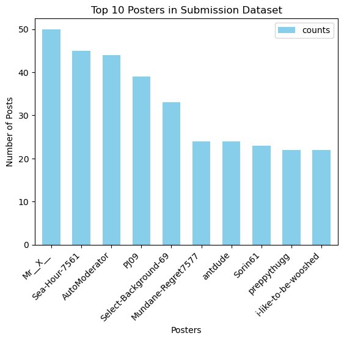

```
[Stage 107:===================================================> (108 + 3) / 111]
```

```
+--------------------+------+
|              author|counts|
+--------------------+------+
|        Flair_Helper| 25677|
|       AutoModerator|  5411|
|                PJ09|  3636|
|            dskatter|  3286|
|            TWYFAN97|  2186|
| infinityandbeyond75|  2186|
|        Generalrossa|  1983|
|Select-Background-69|  1813|
|         newecreator|  1719|
|        tim3assassin|  1690|
+--------------------+------+
```

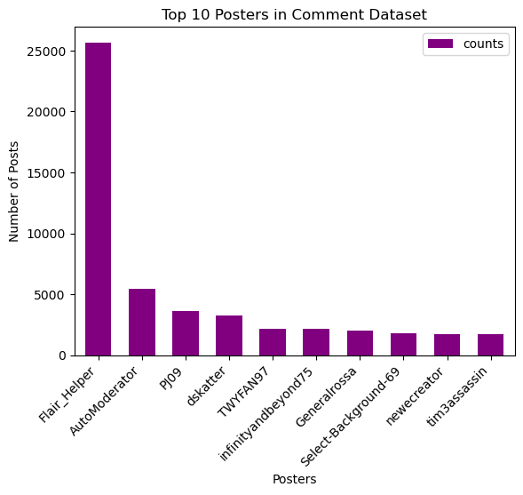

## EDA 2

```
root
 |-- author: string (nullable = true)
 |-- author_flair_css_class: string (nullable = true)
 |-- author_flair_text: string (nullable = true)
 |-- created_utc: timestamp (nullable = true)
 |-- distinguished: string (nullable = true)
 |-- domain: string (nullable = true)
 |-- edited: double (nullable = true)
 |-- id: string (nullable = true)
 |-- is_self: boolean (nullable = true)
 |-- locked: boolean (nullable = true)
 |-- num_comments: long (nullable = true)
 |-- over_18: boolean (nullable = true)
 |-- quarantine: boolean (nullable = true)
 |-- retrieved_on: long (nullable = true)
 |-- score: long (nullable = true)
 |-- selftext: string (nullable = true)
 |-- stickied: boolean (nullable = true)
 |-- subreddit: string (nullable = true)
 |-- subreddit_id: string (nullable = true)
 |-- title: string (nullable = true)
 |-- url: string (nullable = true)
 |-- day_of_week: integer (nullable = true)
 |-- hour: integer (nullable = true)
```

```
root
 |-- day_of_week: integer (nullable = true)
 |-- hour: integer (nullable = true)
 |-- counts: long (nullable = false)
```

```
[Stage 7:==============================================>           (8 + 2) / 10]
```

```
+-----------+----+------+
|day_of_week|hour|counts|
+-----------+----+------+
|          3|  22|   365|
|          3|  15|   377|
|          7|  21|   325|
|          5|  16|   377|
|          4|  10|   214|
|          1|   0|   277|
|          6|  20|   330|
|          6|   1|   277|
|          3|   1|   279|
|          7|   4|   261|
|          2|   2|   302|
|          6|  22|   287|
|          3|  13|   330|
|          2|  19|   378|
|          7|  14|   315|
|          3|  18|   397|
|          1|   7|   177|
|          4|   7|   227|
|          1|  20|   378|
|          7|   1|   284|
+-----------+----+------+
only showing top 20 rows
```

[output not shown]

```
[Stage 45:===================================================>     (9 + 1) / 10]
```

```
+-----------+---+---+---+---+---+---+---+---+---+---+---+---+---+---+---+---+---+---+---+---+---+---+---+---+
|day_of_week|  0|  1|  2|  3|  4|  5|  6|  7|  8|  9| 10| 11| 12| 13| 14| 15| 16| 17| 18| 19| 20| 21| 22| 23|
+-----------+---+---+---+---+---+---+---+---+---+---+---+---+---+---+---+---+---+---+---+---+---+---+---+---+
|          1|277|274|258|232|209|217|209|177|188|156|196|211|243|304|315|339|377|387|393|363|378|342|326|304|
|          2|300|301|302|239|224|243|180|173|186|200|167|219|288|309|325|328|350|376|365|378|387|379|311|286|
|          3|306|279|335|272|238|239|242|238|204|194|244|221|261|330|355|377|382|414|397|411|373|395|365|343|
|          4|287|287|335|289|264|223|181|227|206|194|214|245|265|323|339|390|362|380|373|381|422|420|379|343|
|          5|322|318|335|283|306|250|249|220|229|217|245|279|317|361|377|369|377|397|360|395|345|345|332|321|
|          6|318|277|293|282|233|200|200|173|172|205|182|242|282|336|350|365|354|365|309|357|330|316|287|288|
|          7|306|284|219|232|261|194|208|196|193|203|208|212|254|309|315|322|320|330|335|350|365|325|313|291|
+-----------+---+---+---+---+---+---+---+---+---+---+---+---+---+---+---+---+---+---+---+---+---+---+---+---+
```

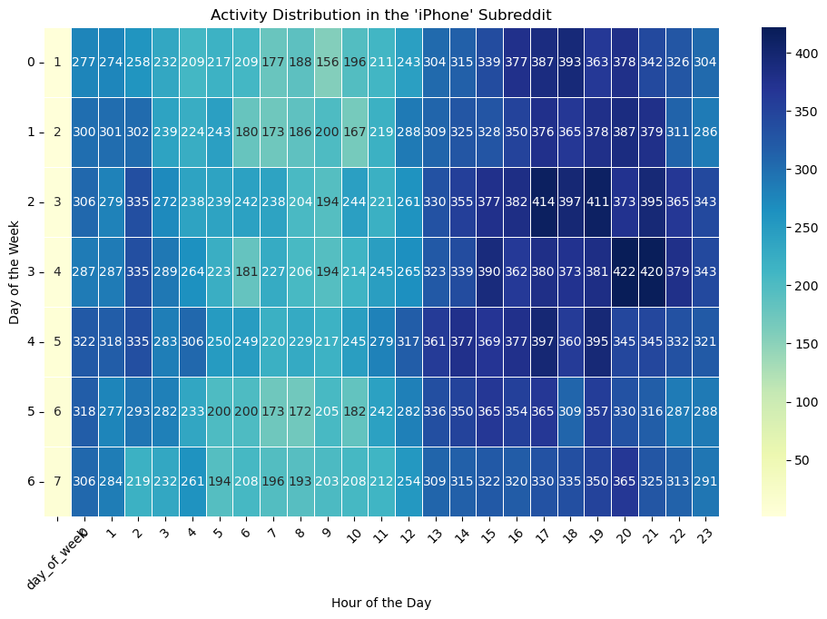

## EDA 3

```
+--------+-----+
| Version|Count|
+--------+-----+
| iphone8|    2|
| iphone9|    0|
|iphone10|    0|
|iphone11|   11|
|iphone12|    6|
|iphone13|   16|
|iphone14|   20|
|iphone15|    3|
+--------+-----+
```

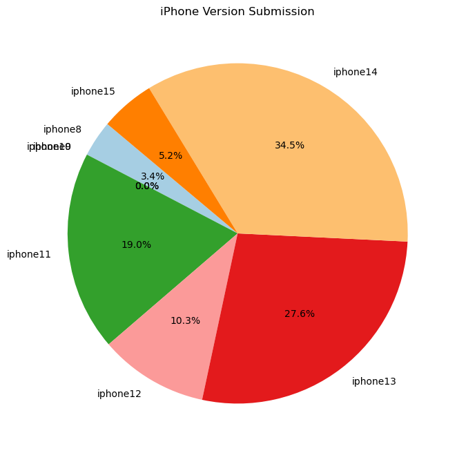

```
+--------+-----+
| Version|Count|
+--------+-----+
| iphone8|   17|
| iphone9|    0|
|iphone10|    1|
|iphone11|   62|
|iphone12|   58|
|iphone13|  182|
|iphone14|   61|
|iphone15|    3|
+--------+-----+
```

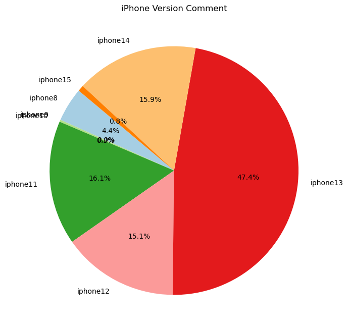